# Wellness Tourism Package: Development of strategies to identify and expand customer base

## Introduction

The 'Visit with us' company has a new product called "Wellness Tourism Package". The package will offer a path to the customer to increase their well-being by giving the ability to kick-start a healthy lifestyle, or enhance their current lifestyle, or assist in maintaining their current healthy lifestyle. The current aim is to expand the customer base by building a viable business model that includes the new product as a path forward.

Background: The company offered 5 tourism packages earlier: Basic, Standard, Deluxe, Super Deluxe, King. The marketing campaign contacted customers at random with no prior analysis. This resulted in 18% of customers buying the packages, however, the marketing cost was high.

### Objective

1. Identifying potential customers who are likely to purchase the Wellness Tourism Package.
2. Generating insights into the characteristics of the customers that would optimize the marketing team's strategies.

### Data Information/Variables

**CustomerID** - the unqiue customer ID  
**ProdTaken** - has value 0/1: customer has not/has purchased a package  
**Age** - age of customer  
**TypeofContact** - company invited or customer did self inquiry  
**CityTier** - describes development/facilities/population of city.There are three ordered tiers, Tier 1> Tier 2 > Tier 3.  
**Occupation** - occupation of customer  
**Gender** - the gender of the customer  
**NumberOfPersonVisiting** - number of people taking the trip with customer  
**PreferredProptertyStar** - preferred hotel rating by customer  
**MaritalStatus** - marital status of the customer  
**NumberOfTrips** - Average number of trips in year by customer  
**Passport** - 0/1 data: customer does not have/has passport  
**OwnCar** - 0/1 data: customer does not have/has a car  
**NumberOfChildrenVisting** - total number of children with age less than 5 who are planning to take the trip with the customer  
**Designation** - designation of the customer in their current organization  
**MonthlyIncome** - gross monthly income of the customer  
**DurationOfPitch** - duration of the pitch by salesperson to customer  
**ProductPitched** - product pitched by the salesperson  
**PitchSatisfactionScore** - the sales pitch satisfaction score  
**NumberOfFollowups** - total number of follow-ups that were done by the sales person after the initial pitch

### The analysis below has the following sections:

1. Loading and importing packages
2. Removing warnings from python notebooks
3. Loading the dataset
4. Preview of the dataset
5. Descriptive statistics for the dataset
6. Exploratory Data Analysis - univariate, bivariate and multivariate analysis
7. Data preprocessing - missing value treatment, outlier treatment, feature engineering, preparation of data for modeling, splitting the data
8. **Bagging Models** - bagging classifier, random forest, decision tree - model building, interpretation of coefficients, performance evaluation, model improvement
9. **Boosting Models** - Adaboost, GradientBoost, XGBoost, Stacking classifiers - model building, identifying key variables, performance evaluation model improvement
10. Insights and recommendations for the marketing department

## 1. Loading and importing packages

```python
# Packages that will be used here include: numpy, pandas, matplotlib, seaborn, sklearn, xgboost

# Import the necessary packages
import numpy as np
import pandas as pd
import matplotlib.pyplot as plt
import seaborn as sns

from sklearn.preprocessing import StandardScaler # for scaling (preprocessing of data)

sns.set(color_codes=True)  # For background of the graphs
%matplotlib inline

# For previewing the data, the columns can be set to limit of None and 100 for the rows.
pd.set_option("display.max_columns", None)
pd.set_option("display.max_rows", 100)

# Below is for splitting the observations for train/test
from sklearn.model_selection import train_test_split

# Below is for decision tree models
from sklearn.tree import DecisionTreeClassifier
from sklearn import tree

# For hyperparameter tuning
from sklearn.model_selection import GridSearchCV

# To get diferent metric scores for decision trees
from sklearn.metrics import (
    f1_score,
    accuracy_score,
    recall_score,
    precision_score,
    confusion_matrix,
    plot_confusion_matrix,
    make_scorer
)

# To get ensemble classifiers
from sklearn.ensemble import AdaBoostClassifier, GradientBoostingClassifier
from sklearn.ensemble import BaggingClassifier
from sklearn.ensemble import RandomForestClassifier
from sklearn.metrics import roc_auc_score

# For automatic structuring/beautification of the python notebook
#%load_ext nb_black
```

### 2. Removing warnings from python notebook

```python
# Removing warnings from the notebook
import warnings

warnings.filterwarnings("ignore")
```

### 3. Loading the dataset

```python
# The dataset is stored in a xlsx file and we want to read it into a pandas dataframe
# By visual inspection of the excel sheet, we know the dataset is in sheet 1.
customerData = pd.read_excel("Tourism.xlsx", index_col=0, sheet_name=1)
# We are using index_col = 0, otherwise the dataframe had the first column as an index, and then"ID" as an index again.
# Using index_col = 0 will make the dataframe have "customerID" as the first column.
print(
    f"The dataframe has {customerData.shape[0]} rows and {customerData.shape[1]} columns."
)
# Using f-string to print the statement for performance reasons
```

```
The dataframe has 4888 rows and 19 columns.
```

### 4. Previewing the dataset

```python
# Preview of the first 5 rows of the dataset
customerData.head()
```

| CustomerID | ProdTaken | Age | TypeofContact | CityTier | DurationOfPitch | Occupation | Gender | NumberOfPersonVisiting | NumberOfFollowups | ProductPitched | PreferredPropertyStar | MaritalStatus | NumberOfTrips | Passport | PitchSatisfactionScore | OwnCar | NumberOfChildrenVisiting | Designation | MonthlyIncome |
| --- | --- | --- | --- | --- | --- | --- | --- | --- | --- | --- | --- | --- | --- | --- | --- | --- | --- | --- | --- |
| 200000 | 1 | 41.0 | Self Enquiry | 3 | 6.0 | Salaried | Female | 3 | 3.0 | Deluxe | 3.0 | Single | 1.0 | 1 | 2 | 1 | 0.0 | Manager | 20993.0 |
| 200001 | 0 | 49.0 | Company Invited | 1 | 14.0 | Salaried | Male | 3 | 4.0 | Deluxe | 4.0 | Divorced | 2.0 | 0 | 3 | 1 | 2.0 | Manager | 20130.0 |
| 200002 | 1 | 37.0 | Self Enquiry | 1 | 8.0 | Free Lancer | Male | 3 | 4.0 | Basic | 3.0 | Single | 7.0 | 1 | 3 | 0 | 0.0 | Executive | 17090.0 |
| 200003 | 0 | 33.0 | Company Invited | 1 | 9.0 | Salaried | Female | 2 | 3.0 | Basic | 3.0 | Divorced | 2.0 | 1 | 5 | 1 | 1.0 | Executive | 17909.0 |
| 200004 | 0 | NaN | Self Enquiry | 1 | 8.0 | Small Business | Male | 2 | 3.0 | Basic | 4.0 | Divorced | 1.0 | 0 | 5 | 1 | 0.0 | Executive | 18468.0 |

#### Observation

The data has 4888 rows and 19 columns. At first glance, we can see that 3 columns have data of the type 0/1 where 0 indicates a "No" and 1 indicates a "Yes".Also, some columns have "NaN" values indicating that data pre-processing will be required.

```python
# Preview of 10 random rows of the dataset
# To see random 10 rows, numpy's random seed was used.
# Putting random.seed to be 1 will return the same random 10 rows everytime we execute the code.
np.random.seed(1)
customerData.sample(n=10)
# The Reason we want to return random rows is so that we can see  the typical values from a random sample.
```

| CustomerID | ProdTaken | Age | TypeofContact | CityTier | DurationOfPitch | Occupation | Gender | NumberOfPersonVisiting | NumberOfFollowups | ProductPitched | PreferredPropertyStar | MaritalStatus | NumberOfTrips | Passport | PitchSatisfactionScore | OwnCar | NumberOfChildrenVisiting | Designation | MonthlyIncome |
| --- | --- | --- | --- | --- | --- | --- | --- | --- | --- | --- | --- | --- | --- | --- | --- | --- | --- | --- | --- |
| 203015 | 0 | 27.0 | Company Invited | 1 | 7.0 | Salaried | Female | 4 | 6.0 | Basic | 3.0 | Married | 5.0 | 0 | 4 | 1 | 3.0 | Executive | 23042.0 |
| 201242 | 0 | 40.0 | Self Enquiry | 3 | 13.0 | Small Business | Male | 2 | 3.0 | King | 4.0 | Single | 2.0 | 0 | 4 | 1 | NaN | VP | 34833.0 |
| 203073 | 0 | 29.0 | Self Enquiry | 2 | 15.0 | Small Business | Male | 4 | 5.0 | Basic | 3.0 | Married | 3.0 | 0 | 2 | 0 | 2.0 | Executive | 23614.0 |
| 200804 | 0 | 48.0 | Company Invited | 1 | 6.0 | Small Business | Male | 2 | 1.0 | Super Deluxe | 3.0 | Single | 3.0 | 0 | 2 | 0 | 0.0 | AVP | 31885.0 |
| 203339 | 0 | 32.0 | Self Enquiry | 1 | 18.0 | Small Business | Male | 4 | 4.0 | Deluxe | 5.0 | Divorced | 3.0 | 1 | 2 | 0 | 3.0 | Manager | 25511.0 |
| 203080 | 1 | 36.0 | Company Invited | 1 | 32.0 | Salaried | Female | 4 | 4.0 | Basic | 4.0 | Married | 3.0 | 1 | 3 | 0 | 1.0 | Executive | 20700.0 |
| 202851 | 0 | 46.0 | Self Enquiry | 1 | 17.0 | Salaried | Male | 4 | 4.0 | Basic | 3.0 | Divorced | 5.0 | 0 | 5 | 1 | 1.0 | Executive | 21332.0 |
| 202883 | 1 | 32.0 | Company Invited | 1 | 27.0 | Salaried | Male | 4 | 4.0 | Standard | 3.0 | Divorced | 5.0 | 0 | 3 | 1 | 1.0 | Senior Manager | 28502.0 |
| 201676 | 0 | 22.0 | Self Enquiry | 1 | 11.0 | Salaried | Male | 2 | 1.0 | Basic | 4.0 | Married | 2.0 | 1 | 4 | 1 | 0.0 | Executive | 17328.0 |
| 201140 | 0 | 44.0 | Self Enquiry | 1 | 13.0 | Small Business | Female | 2 | 3.0 | King | 3.0 | Married | 1.0 | 1 | 4 | 1 | 1.0 | VP | 34049.0 |

#### Observation

The random rows show multiple NaN values. The target variable here will be "ProdTaken" - which is the column that indicates whether customers bought packages (Basic,Standard,Deluxe, Super Deluxe, King) from the "Visit with us" company. A '0' value indicates that the customers did not buy any package, while '1' indicates that the customer bought a package. "Passport" and "OwnCar" columns also have data of the type 0/1. The "CityTier" is an ordered column and is different from the columns that have 0/1 values. The "DurationOfPitch" is likely to be minutes (since this is the salesperson pitching the product to the customer - most likely by phone).

```python
# To see data types and non-null counts for all the columns
customerData.info()
```

```
<class 'pandas.core.frame.DataFrame'>
Int64Index: 4888 entries, 200000 to 204887
Data columns (total 19 columns):
 #   Column                    Non-Null Count  Dtype
---  ------                    --------------  -----
 0   ProdTaken                 4888 non-null   int64
 1   Age                       4662 non-null   float64
 2   TypeofContact             4863 non-null   object
 3   CityTier                  4888 non-null   int64
 4   DurationOfPitch           4637 non-null   float64
 5   Occupation                4888 non-null   object
 6   Gender                    4888 non-null   object
 7   NumberOfPersonVisiting    4888 non-null   int64
 8   NumberOfFollowups         4843 non-null   float64
 9   ProductPitched            4888 non-null   object
 10  PreferredPropertyStar     4862 non-null   float64
 11  MaritalStatus             4888 non-null   object
 12  NumberOfTrips             4748 non-null   float64
 13  Passport                  4888 non-null   int64
 14  PitchSatisfactionScore    4888 non-null   int64
 15  OwnCar                    4888 non-null   int64
 16  NumberOfChildrenVisiting  4822 non-null   float64
 17  Designation               4888 non-null   object
 18  MonthlyIncome             4655 non-null   float64
dtypes: float64(7), int64(6), object(6)
memory usage: 763.8+ KB
```

#### Observation

There are 8 columns that have missing values. However, the target variable "ProdTaken" has no missing values. Multiple columns are of the type float, int, or object and 8 columns will need missing value treatment.

```python
# Finding the sum total of missing values in each of the columns
customerData.isnull().sum().sort_values(ascending=False)
```

```
DurationOfPitch             251
MonthlyIncome               233
Age                         226
NumberOfTrips               140
NumberOfChildrenVisiting     66
NumberOfFollowups            45
PreferredPropertyStar        26
TypeofContact                25
Designation                   0
OwnCar                        0
PitchSatisfactionScore        0
Passport                      0
ProdTaken                     0
MaritalStatus                 0
NumberOfPersonVisiting        0
Gender                        0
Occupation                    0
CityTier                      0
ProductPitched                0
dtype: int64
```

#### Observation

The "DurationOfPitch" column has the maximum number of missing values. Since this is the column that indicates how long the salesperson pitched the data to the customer, one strategy would be to go to the marketing department and ask them to fill the missing observations. If that is not possible, other strategies for imputation can be used. For example, using the median to impute the missing values will be a reasonable strategy. The "MonthlyIncome" column has 233 missing values. We can fill in the missing values using median values again as an approximation. A similar approach can be used for "Age".

### 5. Descriptive statistics for the dataset

```python
# Before starting preprocessing, a look at summary statistics
customerData.describe().T  # taking transpose since it is easier to view
```

|  | count | mean | std | min | 25% | 50% | 75% | max |
| --- | --- | --- | --- | --- | --- | --- | --- | --- |
| ProdTaken | 4888.0 | 0.188216 | 0.390925 | 0.0 | 0.0 | 0.0 | 0.0 | 1.0 |
| Age | 4662.0 | 37.622265 | 9.316387 | 18.0 | 31.0 | 36.0 | 44.0 | 61.0 |
| CityTier | 4888.0 | 1.654255 | 0.916583 | 1.0 | 1.0 | 1.0 | 3.0 | 3.0 |
| DurationOfPitch | 4637.0 | 15.490835 | 8.519643 | 5.0 | 9.0 | 13.0 | 20.0 | 127.0 |
| NumberOfPersonVisiting | 4888.0 | 2.905074 | 0.724891 | 1.0 | 2.0 | 3.0 | 3.0 | 5.0 |
| NumberOfFollowups | 4843.0 | 3.708445 | 1.002509 | 1.0 | 3.0 | 4.0 | 4.0 | 6.0 |
| PreferredPropertyStar | 4862.0 | 3.581037 | 0.798009 | 3.0 | 3.0 | 3.0 | 4.0 | 5.0 |
| NumberOfTrips | 4748.0 | 3.236521 | 1.849019 | 1.0 | 2.0 | 3.0 | 4.0 | 22.0 |
| Passport | 4888.0 | 0.290917 | 0.454232 | 0.0 | 0.0 | 0.0 | 1.0 | 1.0 |
| PitchSatisfactionScore | 4888.0 | 3.078151 | 1.365792 | 1.0 | 2.0 | 3.0 | 4.0 | 5.0 |
| OwnCar | 4888.0 | 0.620295 | 0.485363 | 0.0 | 0.0 | 1.0 | 1.0 | 1.0 |
| NumberOfChildrenVisiting | 4822.0 | 1.187267 | 0.857861 | 0.0 | 1.0 | 1.0 | 2.0 | 3.0 |
| MonthlyIncome | 4655.0 | 23619.853491 | 5380.698361 | 1000.0 | 20346.0 | 22347.0 | 25571.0 | 98678.0 |

#### Observations

```python
#Summary statistics for the non-numerical columns
customerData.describe(include=["object"]).T
```

|  | count | unique | top | freq |
| --- | --- | --- | --- | --- |
| TypeofContact | 4863 | 2 | Self Enquiry | 3444 |
| Occupation | 4888 | 4 | Salaried | 2368 |
| Gender | 4888 | 3 | Male | 2916 |
| ProductPitched | 4888 | 5 | Basic | 1842 |
| MaritalStatus | 4888 | 4 | Married | 2340 |
| Designation | 4888 | 5 | Executive | 1842 |

#### Observations

1. The "TypeOfContact" variable is of the type object, and has 2 unique values.
2. "Occupation" can be treated as a categorical variable here and it has 4 unique values.
3. "Gender" is of type object, and it has 3 unique values.
4. The "ProductPitched" variable can be treated as a categorical variable, with 5 unique variables.
5. The "Designation" can be treated as a categorical variable, and has 5 unique values.
6. The "MaritalStatus" has 4 unique values.
7. As we can see above, other than TypeofContact, there are no missing values in the other variables.

```python
# Descriptive statistics on categorical variables
# Let us take a look at how many of the current customers took a travel package in the last campaign.
customersPackageCount = pd.crosstab(index=customerData["ProdTaken"], columns="count")
customersPackageCount
customersPackageYes = (customersPackageCount.loc[1] / (customerData.shape[0])) * 100
customersPackageYes
print(f"The percentage of customers took a package is {float(customersPackageYes)}.")
```

```
The percentage of customers took a package is 18.821603927986907.
```

#### Observations

When targeted by the marketing department in the last campaign,18.82% of the customers purchased a package (920 customers out of the 4888 customers).

```python
# We can take a look at how many customers are there for company Invited versus self enquiry
TypeofContactCount = pd.crosstab(index=customerData["TypeofContact"], columns="count")
TypeofContactCount
```

| col_0 TypeofContact | count |
| --- | --- |
| Company Invited | 1419 |
| Self Enquiry | 3444 |

#### Observations

The company invited 1419 customers for the packages, however 3444 customers did a self enquiry on the packages offered by the company (i.e. 70% of the customersd did a self enquiry). This indicates higher customer interest in the packages offered by the company.

```python
# We want to take a look at how many customers who did a self enquiry ended up purchasing a package
TypeProdData = pd.crosstab(customerData.TypeofContact, customerData.ProdTaken)
TypeProdData
```

| ProdTaken TypeofContact | 0 | 1 |
| --- | --- | --- |
| Company Invited | 1109 | 310 |
| Self Enquiry | 2837 | 607 |

#### Observations

We can see above that out of the 3444 customers who did a self enquiry about packages, 2837 of them did not purchase any of the packages (i.e. 82% did not purchase a package after making an enquiry). Similarly, when the company invited the customers to look at packages, 1109 out of 1419 customers did not purchase a package.

```python
# To look at the number of unique values in each column:
customerData.nunique()
```

```
ProdTaken                      2
Age                           44
TypeofContact                  2
CityTier                       3
DurationOfPitch               34
Occupation                     4
Gender                         3
NumberOfPersonVisiting         5
NumberOfFollowups              6
ProductPitched                 5
PreferredPropertyStar          3
MaritalStatus                  4
NumberOfTrips                 12
Passport                       2
PitchSatisfactionScore         5
OwnCar                         2
NumberOfChildrenVisiting       4
Designation                    5
MonthlyIncome               2475
dtype: int64
```

#### Observations

We can see that the following columns have only 2 unique values: ProdTaken, TypeofContact,Passport, and OwnCar. Columns that have 3 unique values are CityTier, Gender, PreferredPropertyStar. Columns that have 4 unique values: Occupation, MaritalStatus, NumberOfChildrenVisiting. Columns that have 5 unique values are: NumberOfPersonVisiting, ProductPitched, PitchSatisfactionScore, Designation. While some of these columns are int/float and object, we can convert some of the columns to category columns in data pre-processing section.

```python
# To see the unique value in the columns that have 2 unique values
two_value_cols = ["ProdTaken", "TypeofContact", "Passport", "OwnCar"]
for column in two_value_cols:
    print(customerData[column].value_counts())
    print("*" * 25)
```

```
0    3968
1     920
Name: ProdTaken, dtype: int64
Self Enquiry       3444
Company Invited    1419
Name: TypeofContact, dtype: int64
0    3466
1    1422
Name: Passport, dtype: int64
1    3032
0    1856
Name: OwnCar, dtype: int64
```

#### Observations

920 customers took a package, 3444 customers did a self enquiry. We can see that majority of customers (3466 out of 4888, 70% of customers) did not own a passport. Also, 62% of the customers (3032 customers out of 4888) own a car.

```python
# To see the unique value in the columns that have 3 unique values
three_value_cols = ["CityTier", "Gender", "PreferredPropertyStar"]
for column in three_value_cols:
    print(customerData[column].value_counts().sort_values(ascending=False))
    print("*" * 25)
```

```
1    3190
3    1500
2     198
Name: CityTier, dtype: int64
Male       2916
Female     1817
Fe Male     155
Name: Gender, dtype: int64
3.0    2993
5.0     956
4.0     913
Name: PreferredPropertyStar, dtype: int64
```

#### Observations

Tier 1 was the most popular city tier in the customer base (Tier 1 > Tier 2 > Tier 3 in terms of population/facilities/standard of living). This indicates that the customers (3190 out of 4888), 65% of them, live in cities with facilities, and a higher standard of living. When it comes to Gender, the data shows there are 3 unique values, but as seen above..."Fe Male" is most likely to belong to same category as "Female" and may have been recorded erroneously. The observations for "Fe Male" can be merged with the observations for "Female" and will be taken care of in the data pre processing section. With respect to PreferredPropertyStar, 61% of customers (2993 out of 4888) prefer 3 star properties.

```python
# To see the unique value in the columns that have 4 unique values
four_value_cols = ["Occupation", "MaritalStatus", "NumberOfChildrenVisiting"]
for column in four_value_cols:
    print(customerData[column].value_counts().sort_values(ascending=False))
    print("*" * 25)
```

```
Salaried          2368
Small Business    2084
Large Business     434
Free Lancer          2
Name: Occupation, dtype: int64
Married      2340
Divorced      950
Single        916
Unmarried     682
Name: MaritalStatus, dtype: int64
1.0    2080
2.0    1335
0.0    1082
3.0     325
Name: NumberOfChildrenVisiting, dtype: int64
```

#### Observations

We can see that the 48% (2368 out of 4888) of the customer base is salaried. Free Lancers were only 2 customers. Customers who were married currently were 2340 (47%), while rest were divorced, single or unmarried. 22% of customers (1082 out of 4888) had no children accompany them for their trips, while 2080 (42.5%) had one child attending.

```python
# To see the unique value in the columns that have 5 unique values
five_value_cols = [
    "NumberOfPersonVisiting",
    "ProductPitched",
    "PitchSatisfactionScore",
    "Designation",
]
for column in five_value_cols:
    print(customerData[column].value_counts().sort_values(ascending=False))
    print("*" * 25)
```

```
3    2402
2    1418
4    1026
1      39
5       3
Name: NumberOfPersonVisiting, dtype: int64
Basic           1842
Deluxe          1732
Standard         742
Super Deluxe     342
King             230
Name: ProductPitched, dtype: int64
3    1478
5     970
1     942
4     912
2     586
Name: PitchSatisfactionScore, dtype: int64
Executive         1842
Manager           1732
Senior Manager     742
AVP                342
VP                 230
Name: Designation, dtype: int64
```

#### Observations

We can see that the 49% (2402 out of 4888) of the customer base had 3 people accompany the customer for the trips.When customers were contacted by the company, the marketing department informed the customers about the "Basic" and "Deluxe" packages. For a pitch satisfaction score between 1 and 5, 1478 customers gave a score of 3. Regarding the designation of the customers, it appears that 37.7% of customers (1842 out of 4888) have an executive position.An additional 230 and 342 hold a VP or AVP position (which are usually senior positions in a company).

```python
# To see the unique value in the columns that have 6 unique values
six_value_cols = ["NumberOfFollowups"]
for column in six_value_cols:
    print(customerData[column].value_counts())
    print("*" * 25)
```

```
4.0    2068
3.0    1466
5.0     768
2.0     229
1.0     176
6.0     136
Name: NumberOfFollowups, dtype: int64
```

#### Observations

The marketing department did followups - and a good percentage of them were 4 followups.

```python
# Before we do EDA - we can fix the "Female" and "Fe male" observations in the "Gender" column. This will aid the EDA process.
# Copy the dataframe
customerData1 = customerData.copy()
```

```python
# Converting the "Gender" column so that it has 2 unique values (Male,Female)
# We are writing a user-defined function. The description of the function is in the document string.
def gender_fix(gender_val):
    """This function takes Gender as the input, determines whether the value is "Fe Male" and returns it as "Female"."""
    if isinstance(gender_val, str):  # to check if the gender observation is a string
        if gender_val.startswith("Fe "):  # checks if the value starts with "Fe "
            return str(gender_val.replace("Fe Male", "Female"))
        else:
            return gender_val


customerData1["Gender"] = customerData1["Gender"].apply(gender_fix)
```

```python
# Checking the unique values for the Gender column
customerData1["Gender"].value_counts()
```

```
Male      2916
Female    1972
Name: Gender, dtype: int64
```

### 6. Exploratory Data Analysis - univariate, bivariate and multivariate analysis

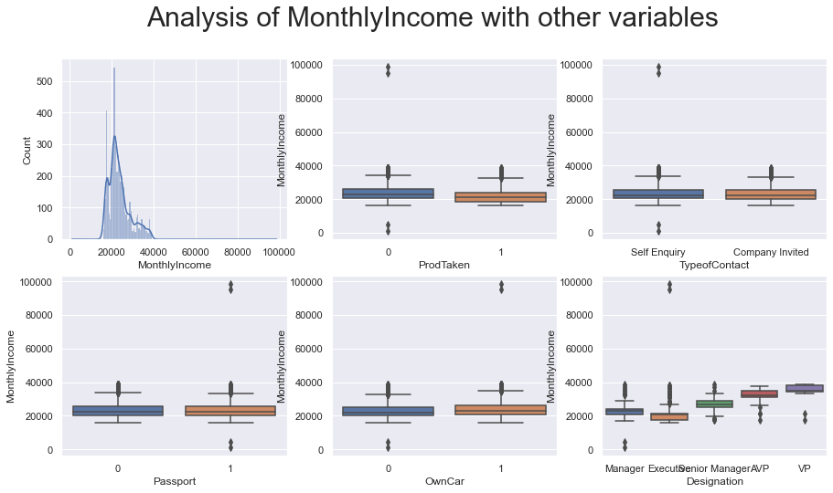

```python
# Univariate and bivariate analysis
# We can start with analysis of 'MonthlyIncome' - histogram and box plots of 'MonthlyIncome'
# versus 'ProdTaken','TypeofContact','Passport', 'OwnCar', "Designation"
#'MonthlyIncome' here is the continous variable
# While variables such as 'Passport' have type int64, they have values of 0 and 1, so we can treat it as a categorical variable.
# Display histogram and boxplots for MonthlyIncome analysis
# Make a grid of 2 rows and 4 columns
fig, axs = plt.subplots(2, 3, figsize=(15, 8))
# Put a figure title
fig.suptitle("Analysis of MonthlyIncome with other variables", fontsize=30)
# Histogram of Income variable
sns.histplot(ax=axs[0, 0], data=customerData1, x="MonthlyIncome", kde=True)
# Box plot for Personal_Loan versus Income
sns.boxplot(
    ax=axs[0, 1],
    data=customerData1,
    x=customerData1["ProdTaken"],
    y=customerData1["MonthlyIncome"],
)
# The remaining boxplots have MonthlyIncome on the y-axis, and the rest of the variables on the x-axis (so treated as categories)

sns.boxplot(
    ax=axs[0, 2],
    data=customerData1,
    x=customerData1["TypeofContact"],
    y=customerData1["MonthlyIncome"],
)

sns.boxplot(
    ax=axs[1, 0],
    data=customerData1,
    x=customerData1["Passport"],
    y=customerData1["MonthlyIncome"],
)
sns.boxplot(
    ax=axs[1, 1],
    data=customerData,
    x=customerData["OwnCar"],
    y=customerData["MonthlyIncome"],
)
sns.boxplot(
    ax=axs[1, 2],
    data=customerData1,
    x=customerData1["Designation"],
    y=customerData1["MonthlyIncome"],
)
# We put semicolons to supress the axis output
```

#### Observations

The range for MonthlyIncome is quite large - from 0 to 100,000. The peak is around 20,000 to 30,000. We can see a few outliers for the remaining graphs - these will be dealt with in the preprocessing section. For TypeofContact, Passport, OwnCar - the medians for whether the customers preferred a typeofContact or had a passport or Owned a car based on their monthlyIncome are not significantly different. For ProdTaken, on the basis of monthlyIncome, there is a slight difference in median. If we look at Designation, we can see that the median monthlyIncome is different between the Manager designation versus a VP type designation.

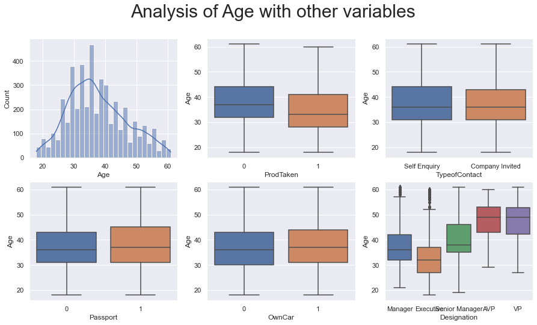

```python
# Univariate and bivariate analysis
# We can start with analysis of 'Age' - histogram and box plots of 'Age'
# versus 'ProdTaken','TypeofContact','Passport', 'OwnCar', "Designation"
#'Age' here is the continous variable
# While variables such as 'Passport' have type int64, they have values of 0 and 1, so we can treat it as a categorical variable.
# Display histogram and boxplots for Age analysis
# Make a grid of 2 rows and 4 columns
fig, axs = plt.subplots(2, 3, figsize=(15, 8))
# Put a figure title
fig.suptitle("Analysis of Age with other variables", fontsize=30)
# Histogram of Income variable
sns.histplot(ax=axs[0, 0], data=customerData1, x="Age", kde=True)
# Box plot for Personal_Loan versus Income
sns.boxplot(
    ax=axs[0, 1],
    data=customerData1,
    x=customerData1["ProdTaken"],
    y=customerData1["Age"],
)
# The remaining boxplots have MonthlyIncome on the y-axis, and the rest of the variables on the x-axis (so treated as categories)

sns.boxplot(
    ax=axs[0, 2],
    data=customerData1,
    x=customerData1["TypeofContact"],
    y=customerData1["Age"],
)

sns.boxplot(
    ax=axs[1, 0],
    data=customerData1,
    x=customerData1["Passport"],
    y=customerData1["Age"],
)
sns.boxplot(
    ax=axs[1, 1],
    data=customerData,
    x=customerData["OwnCar"],
    y=customerData["Age"],
)
sns.boxplot(
    ax=axs[1, 2],
    data=customerData1,
    x=customerData1["Designation"],
    y=customerData1["Age"],
)
# We put semicolons to supress the axis output
```

#### Observations

Age is mostly symmetric distribution with values between 20 and 60. The peak is mostly around 35. There is a slight difference in the median between the ages of customers who took a travel package and who did not take a travel package. There is no significant difference between customers who did a self enquiry and who were invited by a company with respect to age. The same holds for the Passport box plot with age, and OwnCar boxplot with age. We can see outliers in the designation boxplot with age especially for the manager and executive groups. The median age for AVP and VP were much higher than the medians for Manager, Executive and Senior Manager designations.

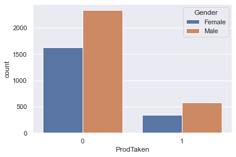

```python
# Analysis between category type variables
sns.countplot(x="ProdTaken", hue="Gender", data=customerData1)
```

#### Observations

The male customers were higher in both groups - groups of customers who bought a travel package and groups of customers who did not buy a travel package.

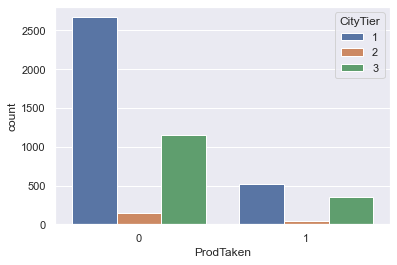

```python
sns.countplot(x="ProdTaken", hue="CityTier", data=customerData1)
```

#### Observations

We can observe that from the customers who bought a travel package, the highest number of them lived in a CityTier1 location. CityTier2 had least representation among customers.

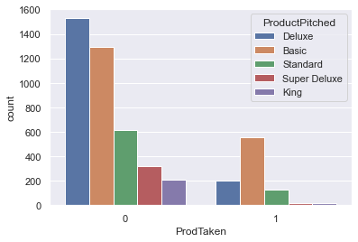

```python
sns.countplot(x="ProdTaken", hue="ProductPitched", data=customerData1)
```

#### Observations

Out of the 5 packages that were offered by the travel company, the "Basic" package was the most popular package among the customers who bought a travel package with "Visit with us". The "Deluxe" followed by "Standard" were the next highest bought packages among the customers.

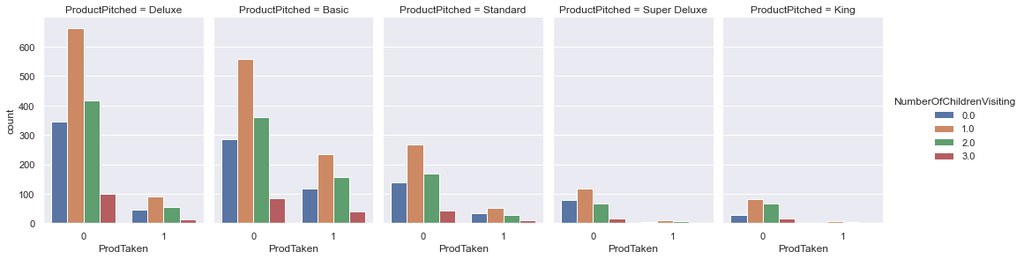

```python
# Analysis using both numerical and categorical variables
g = sns.catplot(
    x="ProdTaken",
    hue="NumberOfChildrenVisiting",
    col="ProductPitched",
    data=customerData1,
    kind="count",
    height=4,
    aspect=0.7,
)
```

#### Observations

Among customers who bought a travel package with "Visit with us", the "Basic" package was bought the highest number of times among all the travel package groups. Among the "Basic" package, as seen above - customers who had 1 or 2 kids outnumber the customers who did not have any kids or had more than 2 kids. The same pattern was seen for "Deluxe" as well.

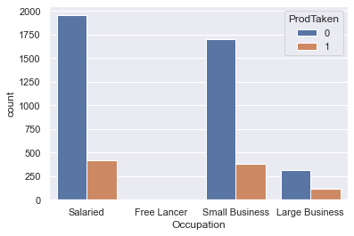

```python
sns.countplot(x="Occupation", hue="ProdTaken", data=customerData1)
```

#### Observations

While the customers who did not take a travel package out number the customers who took a travel package in every occupation, among the customers who did buy a travel package - they belonged to the categories of salaried occupations as well as small business.

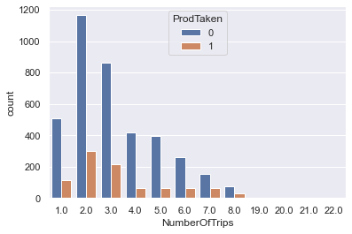

```python
sns.countplot(x="NumberOfTrips", hue="ProdTaken", data=customerData1)
```

#### Observations

We can see a similar type of distribution for NumberOfTrips between customers who took a travel package versus customers who did not take a travel package. Mostly, these customers took 2-3 trips on an average per year.

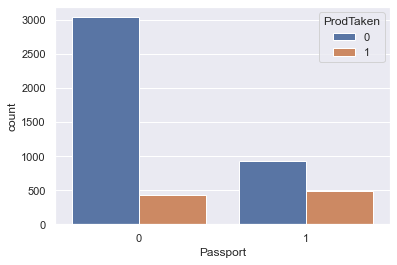

```python
sns.countplot(x="Passport", hue="ProdTaken", data=customerData1)
```

#### Observations

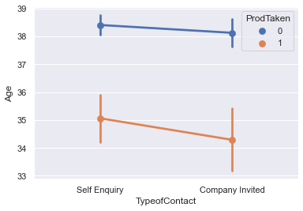

```python
# Analysis using both numerical and categorical variables
sns.pointplot(x="TypeofContact", y="Age", hue="ProdTaken", data=customerData1)
plt.show()
```

#### Observations

While the difference in age is not much, there is a slight difference in age where younger customers were more likely to buy a package as compared to older customers.

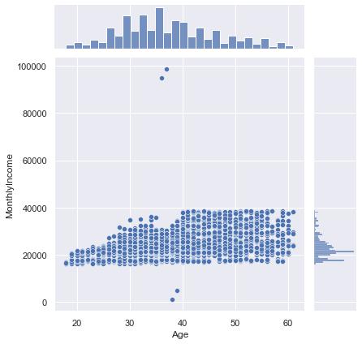

```python
# Bivariate analysis on age and income
sns.jointplot(customerData1["Age"], customerData1["MonthlyIncome"])
```

#### Observations

The monthlyIncome is mostly distributed between 20,000 and 40,000 - and it is spread out between the ages of 18 to 61.

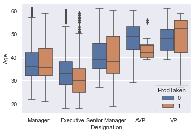

```python
sns.boxplot(
    data=customerData1,
    x=customerData1["Designation"],
    y=customerData1["Age"],
    hue=customerData1["ProdTaken"],
)
```

#### Observations

While there are outliers present in the above graph, we can see that the medians for AVP category are different. The manager category does not seem to have any difference in the median age of customers who bought a travel package and those customers who did not buy a travel package.

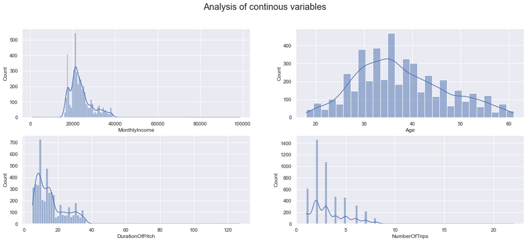

```python
# This section is for displaying the histograms for continous variables
# Make a grid of 2 rows and 4 columns
fig, axs = plt.subplots(2, 2, figsize=(20, 8))
# Put a figure title
fig.suptitle("Analysis of continous variables", fontsize=20)
# Histogram of Income variable
sns.histplot(ax=axs[0, 0], data=customerData1, x="MonthlyIncome", kde=True)
sns.histplot(ax=axs[0, 1], data=customerData1, x="Age", kde=True)
sns.histplot(ax=axs[1, 0], data=customerData1, x="DurationOfPitch", kde=True)
sns.histplot(ax=axs[1, 1], data=customerData1, x="NumberOfTrips", kde=True)


# We put semicolons to supress the axis output
```

#### Observations

We can see that MonthlyIncome and DurationOfPitch and NumberOftrips have outliers. Age is mostly symmetric distribution.

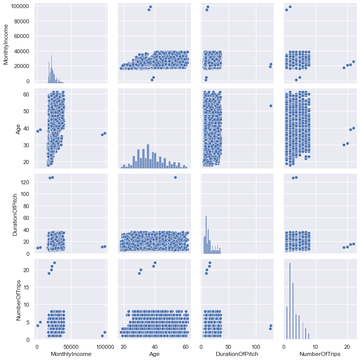

```python
# For the pairplot, we will skip the columns have binary data in the form of "0" and "1" and other category type data
sns.pairplot(
    customerData1,
    x_vars=["MonthlyIncome", "Age", "DurationOfPitch", "NumberOfTrips"],
    y_vars=["MonthlyIncome", "Age", "DurationOfPitch", "NumberOfTrips"],
)
```

#### Observations

As we can see above, there are outliers in the data that make interpretation of the DurationOfPitch, MonthlyIncome and NumberOfTrips to be less straightforward.

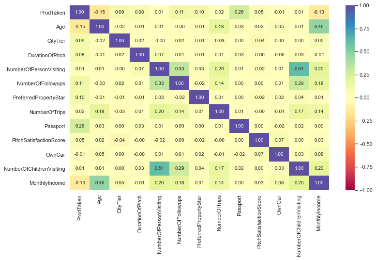

```python
plt.figure(figsize=(12, 7))
sns.heatmap(
    customerData1.corr(), annot=True, vmin=-1, vmax=1, fmt=".2f", cmap="Spectral"
)
plt.show()
```

#### Observations

1. The NumberOfChildrenVisiting is strongly correlated with NumberOfPersonVisiting (0.61). This is likely due to the numbers of children visiting being included in the numbers of persons visiting. However, multicolinearity is not an issue as such for classification problems as it is for linear regression problems.
2. There is moderate correlation between Age and MonthlyIncome (0.46) - meaning that customers who had higher monthly incomes belonged to a higher age group as well.
3. There is some weak correlation between NumberOfChildrenVisiting and NumberOfFollowups, and between NumberOfPersonsVisiting and NumberOfFollowups as well (0.29 and 0.33). Also some weak correlation (0.26) between Passport and ProdTaken variables.

### Observations for customer profile

Based on the EDA analysis, we can conclude that the customer base has high interest in making self-inquiries for travel packages (though this does not always translate to buying a package). They also mostly do not own a passport, but do own a car. A significant portion of the customer base lives in Tier 1 cities - these are cities that have population/facilities. They also prefer 3 star properties, and can be into small business owners or salaried personannel as well. They are also male, younger customers who take 2-3 trips on average per year and the basic package appeals to them.

### 7. Data pre-processing section

This section will have the following subsections:

1. Missing value treatment
2. Conversion of columns that have binary type data ('1','0') to categories
3. Evaluation of outliers and scaling
4. One hot encoding technique for category columns

```python
# 7.1 Missing value treatment
# Evaulation of missing values
customerData1.isnull().sum().sort_values(ascending=False)
```

```
DurationOfPitch             251
MonthlyIncome               233
Age                         226
NumberOfTrips               140
NumberOfChildrenVisiting     66
NumberOfFollowups            45
PreferredPropertyStar        26
TypeofContact                25
Designation                   0
OwnCar                        0
PitchSatisfactionScore        0
Passport                      0
ProdTaken                     0
MaritalStatus                 0
NumberOfPersonVisiting        0
Gender                        0
Occupation                    0
CityTier                      0
ProductPitched                0
dtype: int64
```

#### Observations

DurationOfPitch has 251 observations of missing values, followed by 233 observations of MonthlyIncome which has missing data. Overall, 8 columns have missing data. For missing value treatment, we will impute median values for the columns DurationOfPitch, Age. For MonthlyIncome, we will group by designation and then use the median for that group for imputation. For NumberOfTrips, NumberOfChildrenVisiting,NumberOfFollowups, PreferredPropertyStar - even though these variables are float64, they are discrete values - so we will use the mode to replace the missing values. TypeofContact is an object, so we will use the mode to replace the missing values as well.

```python
# Copying the dataframe again before we impute the values
customerData2 = customerData1.copy()
```

```python
# Imputing values
customerData2["DurationOfPitch"].fillna(
    customerData2["DurationOfPitch"].median(), inplace=True
)
```

```python
# Checking to see missing values
customerData2.isnull().sum().sort_values(ascending=False)
```

```
MonthlyIncome               233
Age                         226
NumberOfTrips               140
NumberOfChildrenVisiting     66
NumberOfFollowups            45
PreferredPropertyStar        26
TypeofContact                25
Designation                   0
OwnCar                        0
PitchSatisfactionScore        0
Passport                      0
ProdTaken                     0
MaritalStatus                 0
NumberOfPersonVisiting        0
Gender                        0
Occupation                    0
DurationOfPitch               0
CityTier                      0
ProductPitched                0
dtype: int64
```

#### Observations

DurationOfPitch has been successfully treated for the missing values and shows 0 in the missing values list.

```python
# MonthlyIncome missing value treatment
customerData2["MonthlyIncome"] = customerData2.groupby(["Designation"])[
    "MonthlyIncome"
].transform(lambda x: x.fillna(x.median()))
```

```python
# Checking to see missing values
customerData2.isnull().sum().sort_values(ascending=False)
```

```
Age                         226
NumberOfTrips               140
NumberOfChildrenVisiting     66
NumberOfFollowups            45
PreferredPropertyStar        26
TypeofContact                25
ProdTaken                     0
Designation                   0
OwnCar                        0
PitchSatisfactionScore        0
Passport                      0
ProductPitched                0
MaritalStatus                 0
NumberOfPersonVisiting        0
Gender                        0
Occupation                    0
DurationOfPitch               0
CityTier                      0
MonthlyIncome                 0
dtype: int64
```

```python
# Imputing values
customerData2["Age"].fillna(customerData2["Age"].median(), inplace=True)
```

```python
# Checking to see missing values
customerData2.isnull().sum().sort_values(ascending=False)
```

```
NumberOfTrips               140
NumberOfChildrenVisiting     66
NumberOfFollowups            45
PreferredPropertyStar        26
TypeofContact                25
ProdTaken                     0
MaritalStatus                 0
Designation                   0
OwnCar                        0
PitchSatisfactionScore        0
Passport                      0
ProductPitched                0
Age                           0
NumberOfPersonVisiting        0
Gender                        0
Occupation                    0
DurationOfPitch               0
CityTier                      0
MonthlyIncome                 0
dtype: int64
```

```python
# Imputing values - we will use the mode here to replace the values
customerData2["NumberOfTrips"].fillna(
    customerData2["NumberOfTrips"].mode()[0], inplace=True
)
#mode returns a series, so we have to take mode()[0] to access the mode value
```

```python
# Checking to see missing values
customerData2.isnull().sum().sort_values(ascending=False)
```

```
NumberOfChildrenVisiting    66
NumberOfFollowups           45
PreferredPropertyStar       26
TypeofContact               25
ProdTaken                    0
MaritalStatus                0
Designation                  0
OwnCar                       0
PitchSatisfactionScore       0
Passport                     0
NumberOfTrips                0
ProductPitched               0
Age                          0
NumberOfPersonVisiting       0
Gender                       0
Occupation                   0
DurationOfPitch              0
CityTier                     0
MonthlyIncome                0
dtype: int64
```

```python
# Imputing values - using mode here
customerData2["NumberOfChildrenVisiting"].fillna(
    customerData2["NumberOfChildrenVisiting"].mode()[0], inplace=True
)
```

```python
# Checking to see missing values
customerData2.isnull().sum().sort_values(ascending=False)
```

```
NumberOfFollowups           45
PreferredPropertyStar       26
TypeofContact               25
ProdTaken                    0
MaritalStatus                0
Designation                  0
NumberOfChildrenVisiting     0
OwnCar                       0
PitchSatisfactionScore       0
Passport                     0
NumberOfTrips                0
ProductPitched               0
Age                          0
NumberOfPersonVisiting       0
Gender                       0
Occupation                   0
DurationOfPitch              0
CityTier                     0
MonthlyIncome                0
dtype: int64
```

```python
# Imputing values
customerData2["NumberOfFollowups"].fillna(
    customerData2["NumberOfFollowups"].mode()[0], inplace=True
)
```

```python
# Checking to see missing values
customerData2.isnull().sum().sort_values(ascending=False)
```

```
PreferredPropertyStar       26
TypeofContact               25
ProdTaken                    0
Designation                  0
NumberOfChildrenVisiting     0
OwnCar                       0
PitchSatisfactionScore       0
Passport                     0
NumberOfTrips                0
MaritalStatus                0
ProductPitched               0
Age                          0
NumberOfFollowups            0
NumberOfPersonVisiting       0
Gender                       0
Occupation                   0
DurationOfPitch              0
CityTier                     0
MonthlyIncome                0
dtype: int64
```

```python
# Imputing values
customerData2["PreferredPropertyStar"].fillna(
    customerData2["PreferredPropertyStar"].mode()[0], inplace=True
)
```

```python
# Checking to see missing values
customerData2.isnull().sum().sort_values(ascending=False)
```

```
TypeofContact               25
ProdTaken                    0
PreferredPropertyStar        0
Designation                  0
NumberOfChildrenVisiting     0
OwnCar                       0
PitchSatisfactionScore       0
Passport                     0
NumberOfTrips                0
MaritalStatus                0
ProductPitched               0
Age                          0
NumberOfFollowups            0
NumberOfPersonVisiting       0
Gender                       0
Occupation                   0
DurationOfPitch              0
CityTier                     0
MonthlyIncome                0
dtype: int64
```

```python
# Imputing values
customerData2["TypeofContact"].fillna(
    customerData2["TypeofContact"].mode()[0], inplace=True
)
```

```python
# Checking to see missing values
customerData2.isnull().sum().sort_values(ascending=False)
```

```
ProdTaken                   0
PreferredPropertyStar       0
Designation                 0
NumberOfChildrenVisiting    0
OwnCar                      0
PitchSatisfactionScore      0
Passport                    0
NumberOfTrips               0
MaritalStatus               0
ProductPitched              0
Age                         0
NumberOfFollowups           0
NumberOfPersonVisiting      0
Gender                      0
Occupation                  0
DurationOfPitch             0
CityTier                    0
TypeofContact               0
MonthlyIncome               0
dtype: int64
```

#### Observations

There are no more missing values in the dataset.

```python
# 7.2 Conversion of columns that have '0' and '1' or categorical data, but have type of 'object'
# For data that has multiple levels, example CityTier, we will not convert to category
# Copy the dataframe before converting columns
customerData3 = customerData2.copy()

cat_vars = [
    "TypeofContact",
    "Occupation",
    "ProductPitched",
    "MaritalStatus",
    "Designation",
    "ProdTaken",
    "Gender",
    "Passport",
    "OwnCar",
]
# the other categorical variables have lots of levels
# and I wouldn't dummy encode them as such

for colname in cat_vars:
    customerData3[colname] = customerData3[colname].astype("category")

customerData3.info()
```

```
<class 'pandas.core.frame.DataFrame'>
Int64Index: 4888 entries, 200000 to 204887
Data columns (total 19 columns):
 #   Column                    Non-Null Count  Dtype
---  ------                    --------------  -----
 0   ProdTaken                 4888 non-null   category
 1   Age                       4888 non-null   float64
 2   TypeofContact             4888 non-null   category
 3   CityTier                  4888 non-null   int64
 4   DurationOfPitch           4888 non-null   float64
 5   Occupation                4888 non-null   category
 6   Gender                    4888 non-null   category
 7   NumberOfPersonVisiting    4888 non-null   int64
 8   NumberOfFollowups         4888 non-null   float64
 9   ProductPitched            4888 non-null   category
 10  PreferredPropertyStar     4888 non-null   float64
 11  MaritalStatus             4888 non-null   category
 12  NumberOfTrips             4888 non-null   float64
 13  Passport                  4888 non-null   category
 14  PitchSatisfactionScore    4888 non-null   int64
 15  OwnCar                    4888 non-null   category
 16  NumberOfChildrenVisiting  4888 non-null   float64
 17  Designation               4888 non-null   category
 18  MonthlyIncome             4888 non-null   float64
dtypes: category(9), float64(7), int64(3)
memory usage: 593.5 KB
```

#### Observations

The data set now has category type data and the remaining are numerical type data.

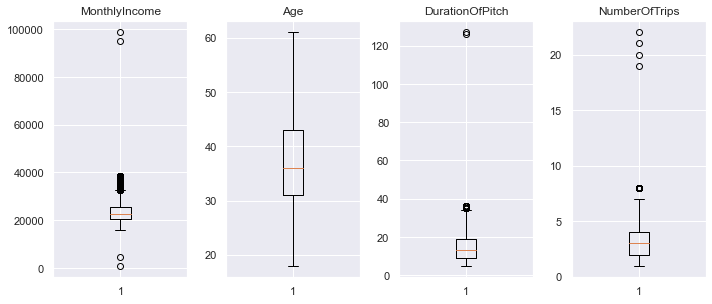

```python
# 7.3 Evaluation of outliers
numerical_col = ["MonthlyIncome", "Age", "DurationOfPitch", "NumberOfTrips"]
plt.figure(figsize=(10, 20))

for i, variable in enumerate(numerical_col):
    plt.subplot(5, 4, i + 1)
    plt.boxplot(customerData3[variable], whis=1.5)
    plt.tight_layout()
    plt.title(variable)

plt.show()
```

#### Observations

For MonthlyIncome, we can see that there are 2 values that are extreme - and can be considered outliers. However, a quick google search reveals that a 100,000 monthly income is possible.Since the observations are only 2 out of 4888, we can cap the values.We can also cap the data for DurationOfPitch and NumberOfTrips as well. The column Age has no outliers.

```python
# MonthlyIncome - we can sort values to see which 2 values are occuring at extreme values
customerData3["MonthlyIncome"].sort_values(ascending=False)
```

```
CustomerID
202482    98678.0
200038    95000.0
202634    38677.0
204104    38677.0
203190    38651.0
           ...
200727    16051.0
201983    16009.0
200513    16009.0
202586     4678.0
200142     1000.0
Name: MonthlyIncome, Length: 4888, dtype: float64
```

```python
# We want to cap the 98,678 and 95,000 values
customerData3["MonthlyIncome"] = customerData3["MonthlyIncome"].clip(upper=38677)
```

```python
# checking to see if MonthlyIncome is capped
customerData3["MonthlyIncome"].sort_values(ascending=False)
```

```
CustomerID
202634    38677.0
204104    38677.0
202482    38677.0
200038    38677.0
203190    38651.0
           ...
200727    16051.0
201983    16009.0
200513    16009.0
202586     4678.0
200142     1000.0
Name: MonthlyIncome, Length: 4888, dtype: float64
```

```python
# We repeat the same procedure with DurationOfPitch and NumberOfTrips
customerData3["DurationOfPitch"].sort_values(ascending=False)
```

```
CustomerID
203878    127.0
201434    126.0
203718     36.0
203768     36.0
204738     36.0
          ...
201901      5.0
201526      5.0
200326      5.0
202326      5.0
202276      5.0
Name: DurationOfPitch, Length: 4888, dtype: float64
```

```python
# We want to cap the 127 and 126 values
customerData3["DurationOfPitch"] = customerData3["DurationOfPitch"].clip(upper=36.0)
```

```python
# checking to see if DurationOfPitch is capped
customerData3["DurationOfPitch"].sort_values(ascending=False)
```

```
CustomerID
203718    36.0
202648    36.0
204662    36.0
204738    36.0
202715    36.0
          ...
201901     5.0
201526     5.0
200326     5.0
202326     5.0
202276     5.0
Name: DurationOfPitch, Length: 4888, dtype: float64
```

```python
# We repeat the same procedure with NumberOfTrips
customerData3["NumberOfTrips"].sort_values(ascending=False)
```

```
CustomerID
203260    22.0
200816    21.0
202829    20.0
200385    19.0
204596     8.0
          ...
201296     1.0
201295     1.0
201285     1.0
201284     1.0
200000     1.0
Name: NumberOfTrips, Length: 4888, dtype: float64
```

```python
# We want to cap the values from 19-22
customerData3["NumberOfTrips"] = customerData3["NumberOfTrips"].clip(upper=8.0)
```

```python
# checking to see if DurationOfPitch is capped
customerData3["NumberOfTrips"].sort_values(ascending=False)
```

```
CustomerID
204596    8.0
203916    8.0
203308    8.0
204260    8.0
204132    8.0
         ...
201296    1.0
201295    1.0
201285    1.0
201284    1.0
200000    1.0
Name: NumberOfTrips, Length: 4888, dtype: float64
```

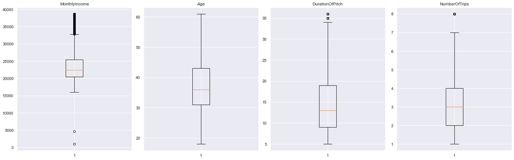

```python
# After capping, looking at the box plots
plt.figure(figsize=(20, 30))

for i, variable in enumerate(numerical_col):
    plt.subplot(5, 4, i + 1)
    plt.boxplot(customerData3[variable], whis=1.5)
    plt.tight_layout()
    plt.title(variable)

plt.show()
```